# L50 maturity

Ricky Tabandera

2/18/2021

## Size at first maturity

L50 or length at which 50% maturity can be calculated using differing methods. Using Data sourced from `survdat` that consist of visual sexual maturity determination and length measurements. Here, L50 is estimated by fitting a logistic generalized linear model to gonadal maturity and body length measurements and estimating the inflection point of the logistic model. This point represents the size where the individual has 50% odds of being mature. Decade variations of this parameter are investigated utilizing decade as a additive and interaction term in the model specification.

The relationship between sexual maturity by body size is a well established life history parameter. L50 is a useful metric in fisheries to identify sizes that are able to reproduce. This information can be used to inform regulation as to minimum catch size that should allow for a significant portion of the population to spawn and contribute genetic information to sustain the stock. Changes in this parameter can signal population/evolutionary pressures on the stock with reduction in this size potentially indicating excessive fishing pressure.

## Model results

If the overall model is significant, there is support for the relationship between sexual maturity and body size. This model can predict the size where there are 50% odds of the indevidual is sexually mature. The results table below displays the L50 for different decades.

|  | Estimate | Odds Ratio | CI (lower) | CI (upper) | Std. Error | z value | Pr(>\|z\|) |  |
| --- | --- | --- | --- | --- | --- | --- | --- | --- |
| (Intercept) | -28.623 | 0.000 | 0.000 | 0.000 | 1.236 | -23.150 | <0.001 | *** |
| LENGTH | 1.087 | 2.966 | 2.717 | 3.255 | 0.046 | 23.580 | <0.001 | *** |
| decade: 1990 | 14.963 | 3149120.161 | 283172.040 | 39785507.061 | 1.261 | 11.867 | <0.001 | *** |
| decade: 2000 | 13.115 | 496252.609 | 44359.483 | 6302429.628 | 1.264 | 10.379 | <0.001 | *** |
| decade: 2010 | 12.371 | 235947.581 | 20663.630 | 3051362.354 | 1.273 | 9.715 | <0.001 | *** |
| LENGTH:decade1990 | -0.469 | 0.626 | 0.569 | 0.685 | 0.047 | -9.897 | <0.001 | *** |
| LENGTH:decade2000 | -0.332 | 0.718 | 0.652 | 0.786 | 0.048 | -6.962 | <0.001 | *** |
| LENGTH:decade2010 | -0.281 | 0.755 | 0.685 | 0.828 | 0.048 | -5.819 | <0.001 | *** |

## L50 across time

The significance of differences among decades can be determined by referencing the model summary table above

|  | 1980 | 1990 | 2000 | 2010 |
| --- | --- | --- | --- | --- |
| Length at 50% maturity | 26.325 | 22.079 | 20.53 | 20.158 |

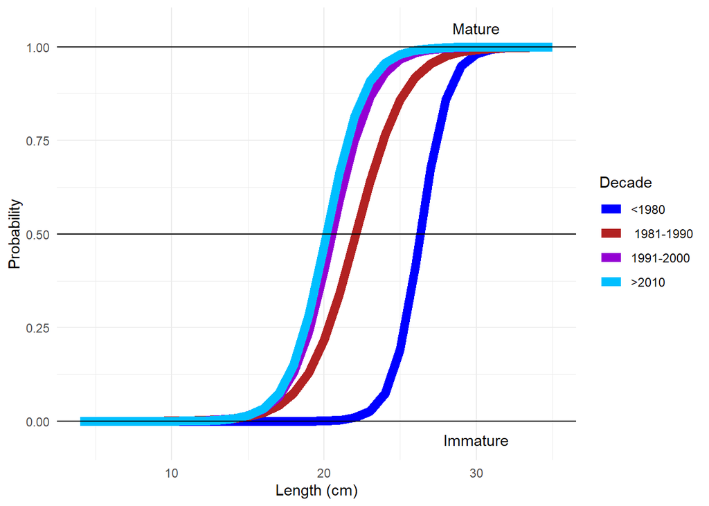